# BN Structure Learning (Cross-Validated)

BPGbio Capstone

2026-07-20

# 1. Load config and data

```r
source(params$config)
cat(sprintf("Network: %s\n", NETWORK_ID))
```

```
## Network: L3b_clinical_curated_olink
```

```r
bn_df <- readRDS(file.path("output", "models", sprintf("%s_data.rds", NETWORK_ID)))
cat(sprintf("Data: %d samples x %d nodes\n", nrow(bn_df), ncol(bn_df)))
```

```
## Data: 87 samples x 59 nodes
```

```r
set.seed(SEED)
```

# 2. Generate blacklist

No edges into root nodes + roots mutually independent. CLG constraint: discrete nodes cannot have continuous parents.

```r
all_nodes <- names(bn_df)
non_roots <- setdiff(all_nodes, ROOTS)

# Rule 1: No edges INTO root nodes (from any node)
bl_into_roots <- expand.grid(from = all_nodes, to = ROOTS, stringsAsFactors = FALSE) %>%
  filter(from != to)

# Rule 2: Roots mutually independent (no edges between roots in either direction)
# Already covered by Rule 1 (roots are in the "to" set), but make explicit:
bl_between_roots <- expand.grid(from = ROOTS, to = ROOTS, stringsAsFactors = FALSE) %>%
  filter(from != to)

# Rule 3: Block edges between WBC and its deterministic components
# (WBC ≈ sum of the differential counts — same collinearity issue as the
# already-excluded NLR variable, but here we keep WBC as a node since it may
# carry non-redundant relationships to other markers, e.g. CRP/ESR).
# Filtered to intersect(all_nodes) since not every network config includes
# wbc or all 5 differential counts (e.g. L1b's curated panel omits basophils) —
# referencing a blacklist node that doesn't exist in bn_df throws an error in
# build.blacklist(), so this must stay defensive across all three configs.
wbc_components <- c("neutrophils", "lymphocytes", "monocytes", "eosinophils", "basophils")
wbc_cluster <- intersect(c("wbc", wbc_components), all_nodes)

if (length(wbc_cluster) >= 2) {
  bl_wbc <- expand.grid(from = wbc_cluster, to = wbc_cluster, stringsAsFactors = FALSE) %>%
    filter(from != to)
  cat(sprintf("WBC cluster present: %s (%d blacklist rows)\n",
              paste(wbc_cluster, collapse = ", "), nrow(bl_wbc)))
} else {
  bl_wbc <- data.frame(from = character(0), to = character(0))
  cat("WBC cluster: fewer than 2 relevant nodes present, no rule applied\n")
}
```

```
## WBC cluster present: wbc, neutrophils, lymphocytes, monocytes, eosinophils (20 blacklist rows)
```

```r
# Rule 4: Block direct parent-child edges in hierarchical modalities (e.g. freq's
# L1/L2/L3 cell-type gating tree). Only applies if the current config defines a
# PARENT_MAP (freq does; clinical/Olink/wb/pb don't) -- defensively checked with
# exists() so this safely no-ops for every other network, the same way the WBC
# rule's intersect() no-ops when wbc_cluster isn't relevant.
if (exists("PARENT_MAP")) {
  child_nodes <- intersect(names(PARENT_MAP), all_nodes)
  bl_hierarchy_rows <- lapply(child_nodes, function(child) {
    parent <- PARENT_MAP[[child]]
    if (parent %in% all_nodes) {
      data.frame(from = c(child, parent), to = c(parent, child), stringsAsFactors = FALSE)
    } else {
      NULL
    }
  })
  bl_hierarchy <- bind_rows(bl_hierarchy_rows)
  cat(sprintf("Hierarchy blacklist (PARENT_MAP): %d parent-child pairs, %d blacklist rows\n",
              nrow(bl_hierarchy) / 2, nrow(bl_hierarchy)))
} else {
  bl_hierarchy <- data.frame(from = character(0), to = character(0))
}

blacklist <- rbind(bl_into_roots, bl_between_roots, bl_wbc, bl_hierarchy) %>% distinct()
cat(sprintf("Blacklist: %d edges forbidden\n", nrow(blacklist)))
```

```
## Blacklist: 194 edges forbidden
```

# 3. Score-based structure learning

## 3a. Hill-climbing

```r
set.seed(SEED)
bn_hc <- hc(bn_df, score = "bic-cg", blacklist = blacklist, maxp = 10)
cat(sprintf("HC: %d edges, BIC-cg = %.2f\n", narcs(bn_hc), score(bn_hc, bn_df, type = "bic-cg")))
```

```
## HC: 179 edges, BIC-cg = -7001.18
```

## 3b. Tabu search

```r
set.seed(SEED)
bn_tabu <- tabu(bn_df, score = "bic-cg", blacklist = blacklist, maxp = 10)
cat(sprintf("Tabu: %d edges, BIC-cg = %.2f\n", narcs(bn_tabu), score(bn_tabu, bn_df, type = "bic-cg")))
```

```
## Tabu: 182 edges, BIC-cg = -6998.47
```

## 3c. MMHC (hybrid)

```r
set.seed(SEED)
bn_mmhc <- mmhc(bn_df, blacklist = blacklist, maximize.args = list(maxp = 10))
cat(sprintf("MMHC: %d edges, BIC-cg = %.2f\n", narcs(bn_mmhc), score(bn_mmhc, bn_df, type = "bic-cg")))
```

```
## MMHC: 54 edges, BIC-cg = -7345.00
```

# 4. Algorithm comparison

```r
# Edge overlap
arcs_hc   <- apply(arcs(bn_hc), 1, paste, collapse = "->")
arcs_tabu <- apply(arcs(bn_tabu), 1, paste, collapse = "->")
arcs_mmhc <- apply(arcs(bn_mmhc), 1, paste, collapse = "->")

all_arcs <- unique(c(arcs_hc, arcs_tabu, arcs_mmhc))
comparison <- data.frame(
  edge = all_arcs,
  hc   = all_arcs %in% arcs_hc,
  tabu = all_arcs %in% arcs_tabu,
  mmhc = all_arcs %in% arcs_mmhc,
  stringsAsFactors = FALSE
) %>%
  mutate(n_agree = hc + tabu + mmhc) %>%
  arrange(desc(n_agree), edge)

cat(sprintf("Total unique edges across algorithms: %d\n", nrow(comparison)))
```

```
## Total unique edges across algorithms: 202
```

```r
cat(sprintf("Edges in all 3: %d\n", sum(comparison$n_agree == 3)))
```

```
## Edges in all 3: 35
```

```r
cat(sprintf("Edges in 2/3: %d\n", sum(comparison$n_agree == 2)))
```

```
## Edges in 2/3: 143
```

```r
cat(sprintf("Edges in 1/3: %d\n", sum(comparison$n_agree == 1)))
```

```
## Edges in 1/3: 24
```

```r
knitr::kable(comparison, caption = "Edge agreement across algorithms")
```

Edge agreement across algorithms

| edge | hc | tabu | mmhc | n_agree |
| --- | --- | --- | --- | --- |
| CCL11->CCL8 | TRUE | TRUE | TRUE | 3 |
| CCL4->GZMB | TRUE | TRUE | TRUE | 3 |
| CXCL10->CXCL11 | TRUE | TRUE | TRUE | 3 |
| CXCL9->CXCL10 | TRUE | TRUE | TRUE | 3 |
| CXCL9->IFNG | TRUE | TRUE | TRUE | 3 |
| CXCL9->PDCD1 | TRUE | TRUE | TRUE | 3 |
| GZMA->LAG3 | TRUE | TRUE | TRUE | 3 |
| IFNG->TNF | TRUE | TRUE | TRUE | 3 |
| IL1RN->IL18 | TRUE | TRUE | TRUE | 3 |
| IL1RN->LEP | TRUE | TRUE | TRUE | 3 |
| IL6->IL1RN | TRUE | TRUE | TRUE | 3 |
| IL7->VEGFA | TRUE | TRUE | TRUE | 3 |
| KLRD1->IL15 | TRUE | TRUE | TRUE | 3 |
| LAG3->rdw | TRUE | TRUE | TRUE | 3 |
| LEP->FGF21 | TRUE | TRUE | TRUE | 3 |
| LEP->eosinophils | TRUE | TRUE | TRUE | 3 |
| PDCD1->IL18 | TRUE | TRUE | TRUE | 3 |
| TNFRSF1A->HAVCR2 | TRUE | TRUE | TRUE | 3 |
| TNFRSF1B->CCL3 | TRUE | TRUE | TRUE | 3 |
| TNFRSF1B->HAVCR2 | TRUE | TRUE | TRUE | 3 |
| VEGFA->CXCL11 | TRUE | TRUE | TRUE | 3 |
| age_group->CCL11 | TRUE | TRUE | TRUE | 3 |
| age_group->GDF15 | TRUE | TRUE | TRUE | 3 |
| age_group->IL10 | TRUE | TRUE | TRUE | 3 |
| age_group->glucose | TRUE | TRUE | TRUE | 3 |
| age_group->ldl | TRUE | TRUE | TRUE | 3 |
| albumin->calcium | TRUE | TRUE | TRUE | 3 |
| alt->ast | TRUE | TRUE | TRUE | 3 |
| creatinine->bun | TRUE | TRUE | TRUE | 3 |
| esr->platelets | TRUE | TRUE | TRUE | 3 |

[output cut: 172 more lines]

# 5. Cross-validated structure learning

Replaces bootstrap resampling with repeated k-fold cross-validation, per sponsor guidance. Bootstrap asked “is this edge stable under resampling?”; cross-validation asks “does this structure generalize to held-out data?” — a direct, more conventional overfitting check.

`bn.cv()` learns a fresh tabu structure on each training fold and scores it against that fold’s held-out data using conditional-Gaussian log-likelihood loss (`"logl"`, bnlearn’s log-likelihood loss — it uses each node’s fitted CLG/discrete distribution automatically based on the data’s own node types, so no separate CLG-specific loss label is needed here). `runs = 10` repeats the whole k-fold procedure 10 times with different fold splits, for ~100 total model fits — noticeably cheaper than the 1000-replicate bootstrap despite each individual tabu search now covering more nodes.

**Note:** this chunk deliberately does NOT use `cache=TRUE` — a prior version of this notebook cached the bootstrap chunk, which caused every network (regardless of which config was passed in) to silently reuse the first cached result. Do not reintroduce caching on this chunk without also keying it to `params$config` (e.g. `cache.extra = tools::md5sum(params$config)`).

```r
set.seed(SEED)
K_FOLDS <- 10
N_RUNS  <- 10

cv_result <- bn.cv(
  bn_df,
  bn = "tabu",
  algorithm.args = list(score = "bic-cg", blacklist = blacklist, maxp = 10),
  loss = "logl",
  method = "k-fold",
  k = K_FOLDS,
  runs = N_RUNS
)

# bn.cv() returns a list of N_RUNS "bn.kcv" objects when runs > 1 (a single
# "bn.kcv" object, itself a list of K_FOLDS folds, when runs == 1). Each fold
# element carries $fitted (a bn.fit learned on that fold's training data) and
# $loss (the held-out loss for that fold).
if (N_RUNS > 1) {
  fold_losses <- unlist(lapply(cv_result, function(run) sapply(run, function(fold) fold$loss)))
  cv_fits <- unlist(lapply(cv_result, function(run) lapply(run, function(fold) fold$fitted)),
                     recursive = FALSE)
} else {
  fold_losses <- sapply(cv_result, function(fold) fold$loss)
  cv_fits <- lapply(cv_result, function(fold) fold$fitted)
}

cat(sprintf("Cross-validation: %d folds x %d runs = %d total fits\n",
            K_FOLDS, N_RUNS, length(cv_fits)))
```

```
## Cross-validation: 10 folds x 10 runs = 100 total fits
```

```r
cat(sprintf("Held-out loss (logl): mean = %.3f, sd = %.3f\n",
            mean(fold_losses), sd(fold_losses)))
```

```
## Held-out loss (logl): mean = 92.224, sd = 7.360
```

```r
# Structure-only versions of each fold's fit, for custom.strength() below
cv_nets <- lapply(cv_fits, bn.net)
```

## 5a. Edge stability across CV folds

`custom.strength()` is the same underlying mechanism `boot.strength()` used — generalized to accept any list of learned DAGs, not just bootstrap replicates. Feeding it the CV-fold structures gives an edge-confidence table in the same format as before, just derived from cross-validation instead of resampling.

```r
cv_str <- custom.strength(cv_nets, nodes = names(bn_df))

cat("CV-derived strength summary:\n")
```

```
## CV-derived strength summary:
```

```r
print(summary(cv_str$strength))
```

```
##    Min. 1st Qu.  Median    Mean 3rd Qu.    Max.
##  0.0000  0.0000  0.0100  0.1054  0.0700  1.0000
```

```r
cat(sprintf("\nDirection probability summary:\n"))
```

```
##
## Direction probability summary:
```

```r
print(summary(cv_str$direction))
```

```
##    Min. 1st Qu.  Median    Mean 3rd Qu.    Max.
##  0.0000  0.0000  0.0000  0.2925  0.7392  1.0000
```

## 5b. Averaged networks at multiple thresholds

```r
# Optimal threshold (bnlearn heuristic)
avg_opt <- averaged.network(cv_str)
thresh_opt <- attr(avg_opt, "threshold")
if (is.null(thresh_opt) || is.na(thresh_opt)) {
  cat("Optimal threshold heuristic returned NA/NULL — falling back to 0.5\n")
  thresh_opt <- 0.5
  avg_opt <- averaged.network(cv_str, threshold = thresh_opt)
}
```

```
## Optimal threshold heuristic returned NA/NULL — falling back to 0.5
```

```r
cat(sprintf("Optimal threshold: %.4f\n", thresh_opt))
```

```
## Optimal threshold: 0.5000
```

```r
cat(sprintf("Averaged network (optimal, t=%.4f): %d edges\n", thresh_opt, narcs(avg_opt)))
```

```
## Averaged network (optimal, t=0.5000): 137 edges
```

```r
# Conservative threshold — CV-appropriate empirical valley, not bootstrap's fixed 0.85
# (CV strengths cluster near 0/1 rather than spreading smoothly like bootstrap's,
# so a fixed 0.85 cutoff doesn't carry the same meaning across pipelines. Find the
# local minimum in the mid-range of the strength distribution instead, per-network.)
#
# Uses binned counts rather than density()/KDE: a smoothed density estimate gets
# pulled toward whichever boundary is closest to the near-1.0 cluster (confirmed
# on L1a, where KDE reported 0.95 — right at the search boundary — while the
# real minimum-count bin was 0.80-0.85). Binning can't overshoot like that.
strengths_mid <- cv_str$strength[cv_str$strength > 0.3 & cv_str$strength < 0.95]
if (length(strengths_mid) >= 5) {
  bin_width <- 0.05
  breaks <- seq(0.3, 0.95, by = bin_width)
  h <- hist(strengths_mid, breaks = breaks, plot = FALSE)
  min_bin <- which.min(h$counts)
  thresh_conservative <- h$mids[min_bin]
  cat(sprintf("Bin counts (0.3-0.95, width %.2f): %s\n",
              bin_width, paste(h$counts, collapse = ", ")))
} else {
  cat("Too few mid-range edge strengths to estimate a valley — falling back to 0.85\n")
  thresh_conservative <- 0.85
}
```

```
## Bin counts (0.3-0.95, width 0.05): 40, 24, 30, 20, 32, 16, 26, 16, 24, 20, 18, 34, 18
```

```r
cat(sprintf("CV-appropriate conservative threshold (empirical valley): %.3f\n", thresh_conservative))
```

```
## CV-appropriate conservative threshold (empirical valley): 0.575
```

```r
avg_conservative <- averaged.network(cv_str, threshold = thresh_conservative)
cat(sprintf("Averaged network (conservative, t=%.4f): %d edges\n", thresh_conservative, narcs(avg_conservative)))
```

```
## Averaged network (conservative, t=0.5750): 117 edges
```

```r
# Liberal threshold (0.50)
avg_50 <- averaged.network(cv_str, threshold = 0.50)
cat(sprintf("Averaged network (t=0.50): %d edges\n", narcs(avg_50)))
```

```
## Averaged network (t=0.50): 137 edges
```

# 6. Edge strength table

```r
# Filter to edges with strength > 0.1 for readability
sig_edges <- cv_str %>%
  filter(strength > 0.1) %>%
  arrange(desc(strength))

knitr::kable(sig_edges, digits = 3,
             caption = "Cross-validated edge strengths (strength > 0.1)")
```

Cross-validated edge strengths (strength > 0.1)

| from | to | strength | direction |
| --- | --- | --- | --- |
| age_group | GDF15 | 1.00 | 1.000 |
| sex | hemoglobin | 1.00 | 1.000 |
| sex | creatinine | 1.00 | 1.000 |
| sex | LEP | 1.00 | 1.000 |
| hemoglobin | sex | 1.00 | 0.000 |
| hemoglobin | hematocrit | 1.00 | 1.000 |
| hdl | triglycerides | 1.00 | 0.910 |
| triglycerides | hdl | 1.00 | 0.090 |
| alt | ast | 1.00 | 1.000 |
| ast | alt | 1.00 | 0.000 |
| albumin | calcium | 1.00 | 1.000 |
| creatinine | sex | 1.00 | 0.000 |
| hematocrit | hemoglobin | 1.00 | 0.000 |
| calcium | albumin | 1.00 | 0.000 |
| CXCL9 | CXCL10 | 1.00 | 1.000 |
| CXCL9 | PDCD1 | 1.00 | 0.720 |
| CXCL10 | CXCL9 | 1.00 | 0.000 |
| IL1RN | LEP | 1.00 | 0.810 |
| IL7 | VEGFA | 1.00 | 0.970 |
| CCL2 | CCL11 | 1.00 | 0.340 |
| CCL11 | CCL2 | 1.00 | 0.660 |
| GDF15 | age_group | 1.00 | 0.000 |
| TNFRSF1A | HAVCR2 | 1.00 | 0.950 |
| TNFRSF1B | HAVCR2 | 1.00 | 0.980 |
| CD8A | GZMA | 1.00 | 0.560 |
| GZMA | CD8A | 1.00 | 0.440 |
| GZMA | LAG3 | 1.00 | 0.960 |
| VEGFA | IL7 | 1.00 | 0.030 |
| PDCD1 | CXCL9 | 1.00 | 0.280 |
| LAG3 | GZMA | 1.00 | 0.040 |

[output cut: 662 more lines]

# 7. DAG visualizations

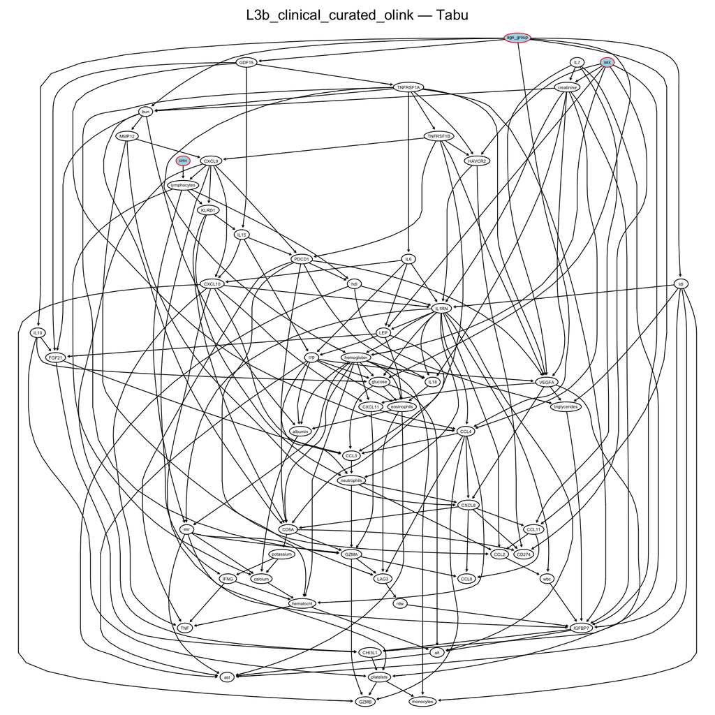

Tabu search DAG

```r
if (requireNamespace("Rgraphviz", quietly = TRUE)) {
  graphviz.plot(bn_tabu, main = sprintf("%s — Tabu", NETWORK_ID),
                shape = "ellipse",
                highlight = list(nodes = ROOTS, fill = "lightblue"))
} else {
  # Fallback: igraph/ggraph
  library(igraph)
  library(ggraph)
  g <- igraph::graph_from_data_frame(arcs(bn_tabu))
  ggraph(g, layout = "fr") +
    geom_edge_link(arrow = arrow(length = unit(3, "mm")), end_cap = circle(3, "mm")) +
    geom_node_point(size = 5, aes(color = name %in% ROOTS)) +
    geom_node_text(aes(label = name), repel = TRUE, size = 3) +
    scale_color_manual(values = c("FALSE" = "grey70", "TRUE" = "lightblue"),
                       guide = "none") +
    labs(title = sprintf("%s — Tabu", NETWORK_ID)) +
    theme_void()
}
```

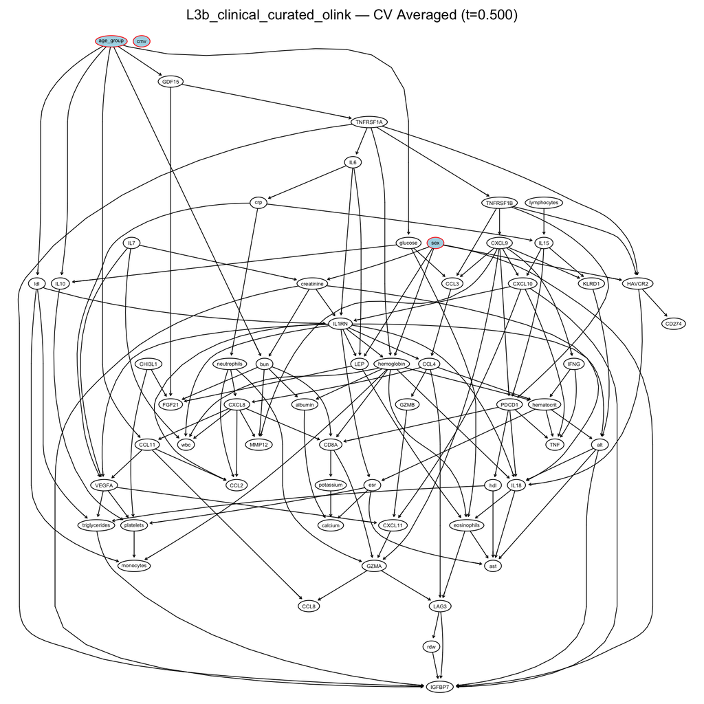

Averaged network (optimal threshold)

```r
if (requireNamespace("Rgraphviz", quietly = TRUE)) {
  graphviz.plot(avg_opt, main = sprintf("%s — CV Averaged (t=%.3f)", NETWORK_ID, thresh_opt),
                shape = "ellipse",
                highlight = list(nodes = ROOTS, fill = "lightblue"))
} else {
  library(igraph)
  library(ggraph)
  g <- igraph::graph_from_data_frame(arcs(avg_opt))
  ggraph(g, layout = "fr") +
    geom_edge_link(arrow = arrow(length = unit(3, "mm")), end_cap = circle(3, "mm")) +
    geom_node_point(size = 5, aes(color = name %in% ROOTS)) +
    geom_node_text(aes(label = name), repel = TRUE, size = 3) +
    scale_color_manual(values = c("FALSE" = "grey70", "TRUE" = "lightblue"),
                       guide = "none") +
    labs(title = sprintf("%s — CV Averaged (t=%.3f)", NETWORK_ID, thresh_opt)) +
    theme_void()
}
```

# 8. Fit parameters and save

```r
# Fit parameters on the tabu DAG (learned on the FULL data, not a CV fold)
fit_tabu <- bn.fit(bn_tabu, bn_df)

# Save everything
models <- list(
  bn_hc            = bn_hc,
  bn_tabu          = bn_tabu,
  bn_mmhc          = bn_mmhc,
  fit_tabu         = fit_tabu,
  cv_str           = cv_str,
  cv_losses        = fold_losses,
  avg_opt          = avg_opt,
  avg_conservative = avg_conservative,
  avg_50           = avg_50,
  blacklist        = blacklist,
  config           = list(
    NETWORK_ID       = NETWORK_ID,
    SEED             = SEED,
    ROOTS            = ROOTS,
    NODE_MAP         = NODE_MAP,
    LOG_TRANSFORM    = LOG_TRANSFORM,
    REFERENCE_LEVELS = REFERENCE_LEVELS,
    K_FOLDS          = K_FOLDS,
    N_RUNS           = N_RUNS
  )
)

out_path <- file.path("output", "models", sprintf("%s_models.rds", NETWORK_ID))
saveRDS(models, out_path)
cat(sprintf("Saved all models: %s\n", out_path))
```

```
## Saved all models: output/models/L3b_clinical_curated_olink_models.rds
```

# 8a. Structured edges dataset for lit review

```r
# Structured edge dataset for AI-assisted literature review

# Extract final consensus DAG edges
final_edges <- data.frame(
  from = arcs(avg_conservative)[, "from"],
  to   = arcs(avg_conservative)[, "to"],
  stringsAsFactors = FALSE
)

# Combine CV edge confidence with final DAG membership
literature_edges <- cv_str %>%
  mutate(
    edge = paste(from, to, sep = " -> "),
    in_final_dag = edge %in% paste(final_edges$from, final_edges$to, sep = " -> ")
  ) %>%
  select(
    from,
    to,
    strength,
    direction,
    in_final_dag
  ) %>%
  arrange(desc(in_final_dag), desc(strength))


# Save structured dataset
write.csv(
  literature_edges,
  file.path(
    "output",
    "models",
    sprintf("%s_literature_edges.csv", NETWORK_ID)
  ),
  row.names = FALSE
)

cat(sprintf(
  "Saved structured literature edge dataset: %s_literature_edges.csv\n",
  NETWORK_ID
))
```

```
## Saved structured literature edge dataset: L3b_clinical_curated_olink_literature_edges.csv
```

# 9. Save DAG figures

```r
fig_dir <- file.path("output", "figures")

# Edge strength histogram
p <- ggplot(cv_str, aes(x = strength)) +
  geom_histogram(bins = 30, fill = "steelblue", color = "white") +
  geom_vline(xintercept = c(0.5, 0.85, thresh_opt),
             linetype = c("dashed", "dashed", "solid"),
             color = c("orange", "red", "darkgreen")) +
  annotate("text", x = 0.5, y = Inf, label = "0.50", vjust = 2, color = "orange") +
  annotate("text", x = 0.85, y = Inf, label = "0.85", vjust = 2, color = "red") +
  annotate("text", x = thresh_opt, y = Inf, label = sprintf("opt=%.2f", thresh_opt),
           vjust = 3.5, color = "darkgreen") +
  labs(title = sprintf("%s — CV Edge Strength Distribution", NETWORK_ID),
       x = "Edge Strength", y = "Count") +
  theme_minimal()

ggsave(file.path(fig_dir, sprintf("%s_edge_strength_hist.png", NETWORK_ID)),
       p, width = 8, height = 5, dpi = 150)
cat("Saved edge strength histogram\n")
```

```
## Saved edge strength histogram
```

```r
# Held-out loss distribution — new, CV-specific diagnostic with no bootstrap
# equivalent. Shows whether generalization performance is stable across folds
# or highly variable (a high-variance loss suggests the model is sensitive to
# exactly which subjects end up in the training set — a red flag given n~90).
p_loss <- ggplot(data.frame(loss = fold_losses), aes(x = loss)) +
  geom_histogram(bins = 20, fill = "darkorange", color = "white") +
  labs(title = sprintf("%s — CV Held-Out Loss Distribution (logl)", NETWORK_ID),
       x = "Held-out loss (lower = better fit)", y = "Count") +
  theme_minimal()

ggsave(file.path(fig_dir, sprintf("%s_cv_loss_hist.png", NETWORK_ID)),
       p_loss, width = 8, height = 5, dpi = 150)
cat("Saved CV loss histogram\n")
```

```
## Saved CV loss histogram
```